# PROJECT

## Prediction which of your Employee will Quit your Company

### Human Resources Analytics

1.Companies that maintain a healthy organization and culture are always a good sign of future prosperity.

2.Recognizing and understanding what factors that were associated with employee turnover will allow companies and individuals to limit this form happening and may even increase employee productivity and growth.

3.These predictive insights give managers the opportunity to take corrective steps to build and preserve their successful business.

### Objective:

The goal is to understand what factors contribute most to employee turnover and create a model that can predict if a certain employee will leave the company or not.

### Precision and Recall/Class Imblance

1.This dataset is an example of a class imblance problem because of the skewed distribution of employee who did and did not leave. More skewed the class means that accuracy breaks down.

In ,this case evaluating our model's algorithm based on accuracy is the wrong thing to measure. We would have to know the different errors that we care about and correct decision. Accuracy alone does not measure an important concept that needs to be taken into consideration in this type of evaluation:

False Positive(Type I Error): You are predict that the employee will leave, but do not.

False Negative(Type II Error): You are predict that the employee will not leave, but does leave.

### Import necessary libraries

```python
import pandas as pd
import numpy as np
import matplotlib.pyplot as plt
import seaborn as sns
import os
```

```python
from sklearn.model_selection import train_test_split
from sklearn.metrics import accuracy_score
from sklearn.neighbors import KNeighborsClassifier
from sklearn.tree import DecisionTreeRegressor
from sklearn.ensemble import RandomForestClassifier
from xgboost import XGBClassifier
from sklearn.linear_model import LogisticRegression
from vecstack import stacking
```

```python
os.chdir("F:\\SSM")
df =pd.read_csv("HR_DATA.csv")
df.head()
```

|  | employee_id | number_project | average_montly_hours | time_spend_company | Work_accident | left | promotion_last_5years | department | salary | satisfaction_level | last_evaluation |
| --- | --- | --- | --- | --- | --- | --- | --- | --- | --- | --- | --- |
| 0 | 1003 | 2 | 157 | 3 | 0 | 1 | 0 | sales | low | 0.38 | 0.53 |
| 1 | 1005 | 5 | 262 | 6 | 0 | 1 | 0 | sales | medium | 0.80 | 0.86 |
| 2 | 1486 | 7 | 272 | 4 | 0 | 1 | 0 | sales | medium | 0.11 | 0.88 |
| 3 | 1038 | 5 | 223 | 5 | 0 | 1 | 0 | sales | low | 0.72 | 0.87 |
| 4 | 1057 | 2 | 159 | 3 | 0 | 1 | 0 | sales | low | 0.37 | 0.52 |

```python
df.shape
```

```
(14999, 11)
```

```python
df.columns
```

```
Index(['employee_id', 'number_project', 'average_montly_hours',
       'time_spend_company', 'Work_accident', 'left', 'promotion_last_5years',
       'department', 'salary', 'satisfaction_level', 'last_evaluation'],
      dtype='object')
```

```python
df.info()
```

```
<class 'pandas.core.frame.DataFrame'>
RangeIndex: 14999 entries, 0 to 14998
Data columns (total 11 columns):
 #   Column                 Non-Null Count  Dtype
---  ------                 --------------  -----
 0   employee_id            14999 non-null  int64
 1   number_project         14999 non-null  int64
 2   average_montly_hours   14999 non-null  int64
 3   time_spend_company     14999 non-null  int64
 4   Work_accident          14999 non-null  int64
 5   left                   14999 non-null  int64
 6   promotion_last_5years  14999 non-null  int64
 7   department             14999 non-null  object
 8   salary                 14999 non-null  object
 9   satisfaction_level     14972 non-null  float64
 10  last_evaluation        14972 non-null  float64
dtypes: float64(2), int64(7), object(2)
memory usage: 1.3+ MB
```

Conclusion : There is null values in column name 'satisfaction_level', last_evaluation' the given dataset.

```python
df['department'].unique()
```

```
array(['sales', 'accounting', 'hr', 'technical', 'support', 'management',
       'IT', 'product_mng', 'marketing', 'RandD'], dtype=object)
```

```python
df['salary'].unique()
```

```
array(['low', 'medium', 'high'], dtype=object)
```

```python
df.describe()
```

|  | employee_id | number_project | average_montly_hours | time_spend_company | Work_accident | left | promotion_last_5years | satisfaction_level | last_evaluation |
| --- | --- | --- | --- | --- | --- | --- | --- | --- | --- |
| count | 14999.000000 | 14999.000000 | 14999.000000 | 14999.000000 | 14999.000000 | 14999.000000 | 14999.000000 | 14972.000000 | 14972.000000 |
| mean | 45424.627575 | 3.803054 | 201.050337 | 3.498233 | 0.144610 | 0.238083 | 0.021268 | 0.612830 | 0.716125 |
| std | 25915.900127 | 1.232592 | 49.943099 | 1.460136 | 0.351719 | 0.425924 | 0.144281 | 0.248714 | 0.171138 |
| min | 1003.000000 | 2.000000 | 96.000000 | 2.000000 | 0.000000 | 0.000000 | 0.000000 | 0.090000 | 0.360000 |
| 25% | 22872.500000 | 3.000000 | 156.000000 | 3.000000 | 0.000000 | 0.000000 | 0.000000 | 0.440000 | 0.560000 |
| 50% | 45448.000000 | 4.000000 | 200.000000 | 3.000000 | 0.000000 | 0.000000 | 0.000000 | 0.640000 | 0.720000 |
| 75% | 67480.500000 | 5.000000 | 245.000000 | 4.000000 | 0.000000 | 0.000000 | 0.000000 | 0.820000 | 0.870000 |
| max | 99815.000000 | 7.000000 | 310.000000 | 10.000000 | 1.000000 | 1.000000 | 1.000000 | 1.000000 | 1.000000 |

```python
df[df.isnull().any(axis=1)]
```

|  | employee_id | number_project | average_montly_hours | time_spend_company | Work_accident | left | promotion_last_5years | department | salary | satisfaction_level | last_evaluation |
| --- | --- | --- | --- | --- | --- | --- | --- | --- | --- | --- | --- |
| 18 | 3794 | 2 | 160 | 3 | 1 | 1 | 1 | sales | low | NaN | NaN |
| 19 | 1140 | 5 | 262 | 5 | 0 | 1 | 0 | sales | low | NaN | 0.89 |
| 33 | 1230 | 2 | 140 | 3 | 0 | 1 | 0 | hr | low | NaN | NaN |
| 53 | 1340 | 2 | 132 | 3 | 0 | 1 | 0 | support | low | NaN | NaN |
| 72 | 22316 | 2 | 149 | 3 | 0 | 1 | 0 | product_mng | high | NaN | NaN |
| 92 | 1581 | 2 | 143 | 3 | 0 | 1 | 0 | sales | low | NaN | NaN |
| 107 | 17376 | 2 | 148 | 3 | 0 | 1 | 0 | accounting | medium | NaN | NaN |
| 120 | 1739 | 4 | 158 | 4 | 1 | 1 | 0 | technical | low | NaN | NaN |
| 137 | 1847 | 2 | 129 | 3 | 0 | 1 | 0 | management | low | NaN | NaN |
| 175 | 32923 | 4 | 164 | 2 | 0 | 1 | 0 | sales | low | NaN | NaN |
| 191 | 2160 | 4 | 226 | 6 | 1 | 1 | 0 | technical | medium | 0.92 | NaN |
| 352 | 3150 | 4 | 262 | 6 | 0 | 1 | 0 | support | low | NaN | 0.91 |
| 376 | 3250 | 4 | 296 | 2 | 0 | 1 | 0 | IT | medium | 0.56 | NaN |
| 402 | 3405 | 5 | 275 | 5 | 0 | 1 | 0 | sales | low | NaN | 1.00 |
| 427 | 78130 | 3 | 180 | 4 | 0 | 1 | 0 | technical | medium | NaN | 0.60 |
| 442 | 3635 | 5 | 229 | 5 | 0 | 1 | 0 | management | low | 0.77 | NaN |
| 468 | 3755 | 5 | 245 | 5 | 0 | 1 | 0 | sales | low | NaN | 0.92 |
| 543 | 4150 | 5 | 237 | 5 | 0 | 1 | 0 | sales | medium | 0.89 | NaN |
| 892 | 43615 | 4 | 276 | 5 | 0 | 1 | 0 | support | low | 0.74 | NaN |
| 1588 | 42185 | 5 | 264 | 5 | 0 | 1 | 0 | IT | medium | NaN | 0.81 |
| 1934 | 11895 | 4 | 225 | 5 | 0 | 1 | 0 | sales | medium | 0.78 | NaN |
| 2343 | 14170 | 3 | 115 | 2 | 1 | 0 | 0 | support | low | NaN | 0.97 |
| 2743 | 16445 | 5 | 149 | 2 | 0 | 0 | 0 | RandD | low | 0.62 | NaN |
| 3170 | 18980 | 5 | 186 | 2 | 0 | 0 | 0 | technical | medium | NaN | NaN |
| 3609 | 21580 | 3 | 263 | 2 | 1 | 0 | 0 | sales | medium | 0.95 | NaN |
| 3776 | 22555 | 4 | 214 | 3 | 0 | 0 | 0 | technical | medium | NaN | 0.68 |
| 4122 | 24505 | 3 | 192 | 3 | 0 | 0 | 0 | marketing | high | 0.86 | NaN |
| 4740 | 27950 | 3 | 253 | 3 | 0 | 0 | 0 | marketing | medium | NaN | 0.95 |
| 5028 | 29640 | 4 | 180 | 4 | 0 | 0 | 0 | product_mng | medium | 0.64 | NaN |
| 6453 | 38090 | 5 | 166 | 2 | 0 | 0 | 0 | technical | high | NaN | 0.78 |
| 7005 | 41535 | 4 | 150 | 3 | 0 | 0 | 0 | technical | low | 0.82 | NaN |
| 7516 | 44460 | 4 | 264 | 3 | 0 | 0 | 0 | technical | low | NaN | 0.97 |
| 8630 | 50960 | 4 | 167 | 3 | 1 | 0 | 0 | technical | low | 0.90 | NaN |
| 9455 | 55770 | 4 | 270 | 3 | 0 | 0 | 0 | product_mng | low | NaN | 0.88 |
| 9901 | 58630 | 5 | 252 | 3 | 0 | 0 | 0 | support | medium | 0.92 | NaN |
| 10647 | 62595 | 4 | 165 | 3 | 0 | 0 | 0 | technical | low | NaN | 0.69 |
| 10962 | 64350 | 5 | 233 | 3 | 0 | 0 | 0 | support | low | 0.65 | NaN |
| 11575 | 20215 | 3 | 192 | 7 | 0 | 0 | 0 | management | high | NaN | NaN |
| 11967 | 70005 | 3 | 148 | 3 | 0 | 0 | 0 | IT | low | 0.82 | NaN |
| 12422 | 72475 | 5 | 257 | 5 | 0 | 1 | 0 | technical | medium | NaN | 1.00 |
| 12853 | 74880 | 3 | 136 | 2 | 0 | 0 | 0 | hr | high | NaN | 0.70 |
| 13482 | 78780 | 3 | 207 | 7 | 0 | 0 | 1 | management | medium | 0.58 | NaN |
| 13925 | 81315 | 3 | 133 | 3 | 0 | 0 | 0 | sales | medium | NaN | 0.75 |

Fill NAN values in the given dataset by Mean of that column because there is no more dispersion.

```python
df.fillna(df.mean(),inplace=True)
```

```python
df[df.isnull().any(axis=1)]
```

|  | employee_id | number_project | average_montly_hours | time_spend_company | Work_accident | left | promotion_last_5years | department | salary | satisfaction_level | last_evaluation |
| --- | --- | --- | --- | --- | --- | --- | --- | --- | --- | --- | --- |

From above df having one NAN observation no.18 to check it is filled with mean or not

```python
df.loc[df['employee_id']==3794]
```

|  | employee_id | number_project | average_montly_hours | time_spend_company | Work_accident | left | promotion_last_5years | department | salary | satisfaction_level | last_evaluation |
| --- | --- | --- | --- | --- | --- | --- | --- | --- | --- | --- | --- |
| 18 | 3794 | 2 | 160 | 3 | 1 | 1 | 1 | sales | low | 0.61283 | 0.716125 |

We have successfully filled NAN values in the dataset

```python
df.info()
```

```
<class 'pandas.core.frame.DataFrame'>
RangeIndex: 14999 entries, 0 to 14998
Data columns (total 11 columns):
 #   Column                 Non-Null Count  Dtype
---  ------                 --------------  -----
 0   employee_id            14999 non-null  int64
 1   number_project         14999 non-null  int64
 2   average_montly_hours   14999 non-null  int64
 3   time_spend_company     14999 non-null  int64
 4   Work_accident          14999 non-null  int64
 5   left                   14999 non-null  int64
 6   promotion_last_5years  14999 non-null  int64
 7   department             14999 non-null  object
 8   salary                 14999 non-null  object
 9   satisfaction_level     14999 non-null  float64
 10  last_evaluation        14999 non-null  float64
dtypes: float64(2), int64(7), object(2)
memory usage: 1.3+ MB
```

Now there is no any NAN values in the given dataset

We drop 'employee_id' column which is not important when applying algorithm

```python
df.drop(columns='employee_id',inplace=True)
```

```python
df
```

|  | number_project | average_montly_hours | time_spend_company | Work_accident | left | promotion_last_5years | department | salary | satisfaction_level | last_evaluation |
| --- | --- | --- | --- | --- | --- | --- | --- | --- | --- | --- |
| 0 | 2 | 157 | 3 | 0 | 1 | 0 | sales | low | 0.38 | 0.53 |
| 1 | 5 | 262 | 6 | 0 | 1 | 0 | sales | medium | 0.80 | 0.86 |
| 2 | 7 | 272 | 4 | 0 | 1 | 0 | sales | medium | 0.11 | 0.88 |
| 3 | 5 | 223 | 5 | 0 | 1 | 0 | sales | low | 0.72 | 0.87 |
| 4 | 2 | 159 | 3 | 0 | 1 | 0 | sales | low | 0.37 | 0.52 |
| ... | ... | ... | ... | ... | ... | ... | ... | ... | ... | ... |
| 14994 | 2 | 151 | 3 | 0 | 1 | 0 | support | low | 0.40 | 0.57 |
| 14995 | 2 | 160 | 3 | 0 | 1 | 0 | support | low | 0.37 | 0.48 |
| 14996 | 2 | 143 | 3 | 0 | 1 | 0 | support | low | 0.37 | 0.53 |
| 14997 | 6 | 280 | 4 | 0 | 1 | 0 | support | low | 0.11 | 0.96 |
| 14998 | 2 | 158 | 3 | 0 | 1 | 0 | support | low | 0.37 | 0.52 |

14999 rows × 10 columns

```python
df['department'].value_counts()
```

```
sales          4140
technical      2720
support        2229
IT             1227
product_mng     902
marketing       858
RandD           787
accounting      767
hr              739
management      630
Name: department, dtype: int64
```

```python
df.groupby('department').sum()
```

| department | number_project | average_montly_hours | time_spend_company | Work_accident | left | promotion_last_5years | satisfaction_level | last_evaluation |
| --- | --- | --- | --- | --- | --- | --- | --- | --- |
| IT | 4683 | 248119 | 4256 | 164 | 273 | 3 | 758.17283 | 879.452250 |
| RandD | 3033 | 158030 | 2650 | 134 | 121 | 27 | 487.80000 | 560.446125 |
| accounting | 2934 | 154292 | 2702 | 96 | 204 | 14 | 446.68283 | 550.706125 |
| hr | 2701 | 146828 | 2480 | 89 | 215 | 15 | 442.53566 | 524.006125 |
| management | 2432 | 126787 | 2711 | 103 | 91 | 69 | 391.76566 | 456.234499 |
| marketing | 3164 | 171073 | 3063 | 138 | 203 | 43 | 530.62283 | 613.946125 |
| product_mng | 3434 | 180369 | 3135 | 132 | 198 | 0 | 559.19566 | 644.662250 |
| sales | 15634 | 831773 | 14631 | 587 | 1014 | 100 | 2543.77981 | 2938.236749 |
| support | 8479 | 447490 | 7563 | 345 | 555 | 20 | 1377.90849 | 1611.534499 |
| technical | 10548 | 550793 | 9279 | 381 | 697 | 28 | 1653.37264 | 1961.930624 |

```python
df.groupby('department').mean()
```

| department | number_project | average_montly_hours | time_spend_company | Work_accident | left | promotion_last_5years | satisfaction_level | last_evaluation |
| --- | --- | --- | --- | --- | --- | --- | --- | --- |
| IT | 3.816626 | 202.215974 | 3.468623 | 0.133659 | 0.222494 | 0.002445 | 0.617908 | 0.716750 |
| RandD | 3.853875 | 200.800508 | 3.367217 | 0.170267 | 0.153748 | 0.034307 | 0.619822 | 0.712130 |
| accounting | 3.825293 | 201.162973 | 3.522816 | 0.125163 | 0.265971 | 0.018253 | 0.582377 | 0.718000 |
| hr | 3.654939 | 198.684709 | 3.355886 | 0.120433 | 0.290934 | 0.020298 | 0.598830 | 0.709075 |
| management | 3.860317 | 201.249206 | 4.303175 | 0.163492 | 0.144444 | 0.109524 | 0.621850 | 0.724182 |
| marketing | 3.687646 | 199.385781 | 3.569930 | 0.160839 | 0.236597 | 0.050117 | 0.618442 | 0.715555 |
| product_mng | 3.807095 | 199.965632 | 3.475610 | 0.146341 | 0.219512 | 0.000000 | 0.619951 | 0.714703 |
| sales | 3.776329 | 200.911353 | 3.534058 | 0.141787 | 0.244928 | 0.024155 | 0.614440 | 0.709719 |
| support | 3.803948 | 200.758188 | 3.393001 | 0.154778 | 0.248991 | 0.008973 | 0.618173 | 0.722985 |
| technical | 3.877941 | 202.497426 | 3.411397 | 0.140074 | 0.256250 | 0.010294 | 0.607858 | 0.721298 |

```python
df['left'].value_counts()
```

```
0    11428
1     3571
Name: left, dtype: int64
```

### Conclusion:

There are 3571 employees are left and 11428 employees are stay.

# 1.Data Visualization

#### By plotting correlation we can understand correlation of Target variable "Left" with other variable

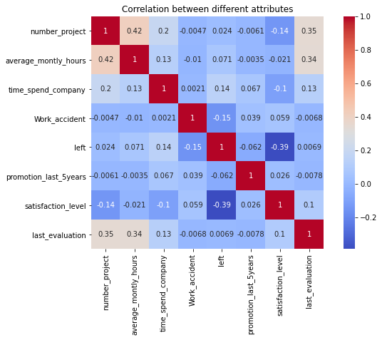

```python
plt.figure(figsize=(10,6))
sns.heatmap(df.corr(),vmax=1,square=True,annot=True,cmap='coolwarm')
plt.title('Correlation between different attributes')
plt.show()
```

### Conclusion:

1.Satisfaction level is most important reason why somebody have left Company

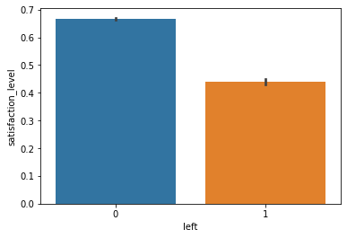

```python
sns.barplot(x='left',y='satisfaction_level',data=df)
```

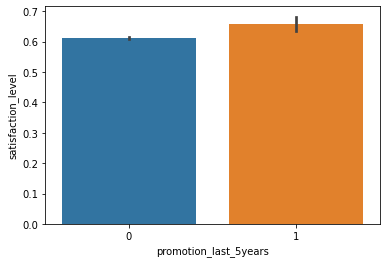

```python
sns.barplot(x='promotion_last_5years',y='satisfaction_level',data=df)
```

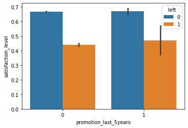

```python
sns.barplot(x='promotion_last_5years',y='satisfaction_level',data=df,hue='left')
```

### Conclusion:

By observing above we conclude that pramotion and satisfaction level are related to each other.

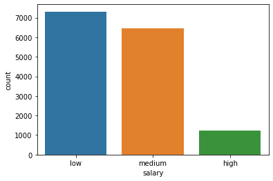

```python
sns.countplot('salary',data = df)
plt.show()
```

### Conclusion:

By observing we conclude that there are three type of salary and frequency of low and medium are greater than high.

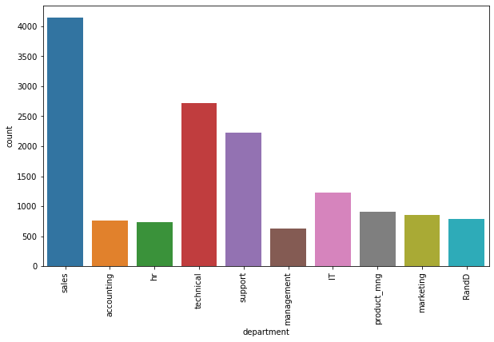

```python
plt.figure(figsize=(10,6))
sns.countplot(df.department)
plt.xticks(rotation=90)
```

### Conclusion:

By observing we conclude that there are 10 types of department and frequency of sales,technical,support are high than others.

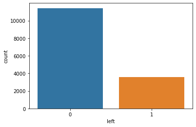

```python
sns.countplot('left',data = df)
plt.show()
```

### Conclusion:

By observing we conclude that frequency of employee stay are high than left.

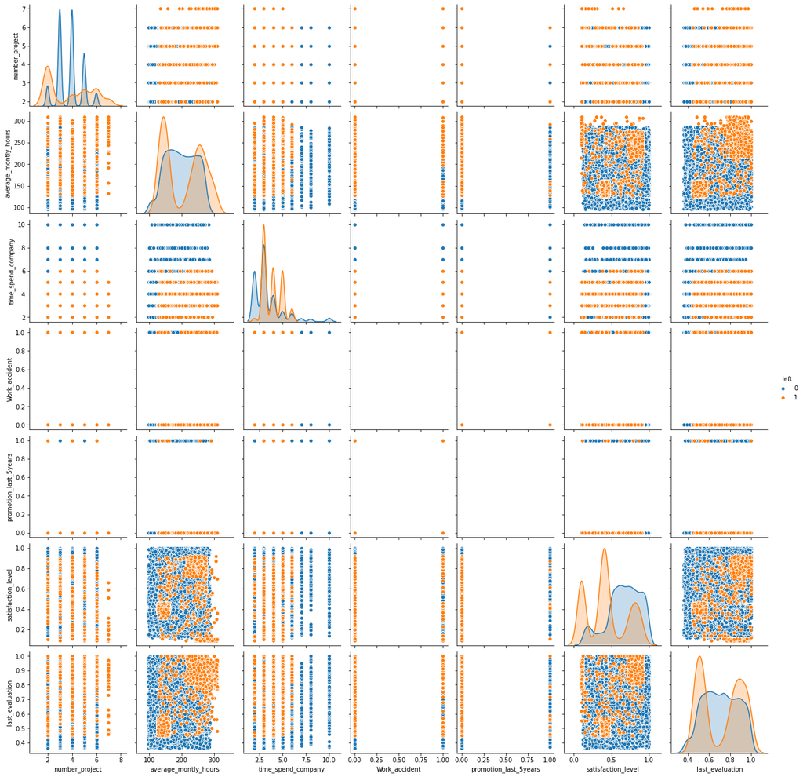

```python
sns.pairplot(df,hue='left')
```

### Conclusion:

1.In last_Evaluation Satisfaction level is high they did not left and those who left satisfaction level is low but few people left.

2.But now satisfaction level is high but people left.

3.We are written some conclusion by observing we can write more conclusion about which reasion person left company.

# 2.Data Preprocessing

### Label Encoding

```python
from sklearn.preprocessing import LabelEncoder

label = LabelEncoder()

df['salary'] = label.fit_transform(df['salary'])

df.head()
```

|  | number_project | average_montly_hours | time_spend_company | Work_accident | left | promotion_last_5years | department | salary | satisfaction_level | last_evaluation |
| --- | --- | --- | --- | --- | --- | --- | --- | --- | --- | --- |
| 0 | 2 | 157 | 3 | 0 | 1 | 0 | sales | 1 | 0.38 | 0.53 |
| 1 | 5 | 262 | 6 | 0 | 1 | 0 | sales | 2 | 0.80 | 0.86 |
| 2 | 7 | 272 | 4 | 0 | 1 | 0 | sales | 2 | 0.11 | 0.88 |
| 3 | 5 | 223 | 5 | 0 | 1 | 0 | sales | 1 | 0.72 | 0.87 |
| 4 | 2 | 159 | 3 | 0 | 1 | 0 | sales | 1 | 0.37 | 0.52 |

```python
from sklearn.preprocessing import LabelEncoder

label = LabelEncoder()

df['department'] = label.fit_transform(df['department'])

df.head()
```

|  | number_project | average_montly_hours | time_spend_company | Work_accident | left | promotion_last_5years | department | salary | satisfaction_level | last_evaluation |
| --- | --- | --- | --- | --- | --- | --- | --- | --- | --- | --- |
| 0 | 2 | 157 | 3 | 0 | 1 | 0 | 7 | 1 | 0.38 | 0.53 |
| 1 | 5 | 262 | 6 | 0 | 1 | 0 | 7 | 2 | 0.80 | 0.86 |
| 2 | 7 | 272 | 4 | 0 | 1 | 0 | 7 | 2 | 0.11 | 0.88 |
| 3 | 5 | 223 | 5 | 0 | 1 | 0 | 7 | 1 | 0.72 | 0.87 |
| 4 | 2 | 159 | 3 | 0 | 1 | 0 | 7 | 1 | 0.37 | 0.52 |

### Get dummy variables

```python
df = pd.get_dummies(df,columns =['department','salary'])
df.dtypes
```

```
number_project             int64
average_montly_hours       int64
time_spend_company         int64
Work_accident              int64
left                       int64
promotion_last_5years      int64
satisfaction_level       float64
last_evaluation          float64
department_0               uint8
department_1               uint8
department_2               uint8
department_3               uint8
department_4               uint8
department_5               uint8
department_6               uint8
department_7               uint8
department_8               uint8
department_9               uint8
salary_0                   uint8
salary_1                   uint8
salary_2                   uint8
dtype: object
```

```python
df.head()
```

|  | number_project | average_montly_hours | time_spend_company | Work_accident | left | promotion_last_5years | satisfaction_level | last_evaluation | department_0 | department_1 | ... | department_3 | department_4 | department_5 | department_6 | department_7 | department_8 | department_9 | salary_0 | salary_1 | salary_2 |
| --- | --- | --- | --- | --- | --- | --- | --- | --- | --- | --- | --- | --- | --- | --- | --- | --- | --- | --- | --- | --- | --- |
| 0 | 2 | 157 | 3 | 0 | 1 | 0 | 0.38 | 0.53 | 0 | 0 | ... | 0 | 0 | 0 | 0 | 1 | 0 | 0 | 0 | 1 | 0 |
| 1 | 5 | 262 | 6 | 0 | 1 | 0 | 0.80 | 0.86 | 0 | 0 | ... | 0 | 0 | 0 | 0 | 1 | 0 | 0 | 0 | 0 | 1 |
| 2 | 7 | 272 | 4 | 0 | 1 | 0 | 0.11 | 0.88 | 0 | 0 | ... | 0 | 0 | 0 | 0 | 1 | 0 | 0 | 0 | 0 | 1 |
| 3 | 5 | 223 | 5 | 0 | 1 | 0 | 0.72 | 0.87 | 0 | 0 | ... | 0 | 0 | 0 | 0 | 1 | 0 | 0 | 0 | 1 | 0 |
| 4 | 2 | 159 | 3 | 0 | 1 | 0 | 0.37 | 0.52 | 0 | 0 | ... | 0 | 0 | 0 | 0 | 1 | 0 | 0 | 0 | 1 | 0 |

5 rows × 21 columns

### For easy splitting dataset we take 'left' column at last

```python
df1 = df['left']
df = df.drop(['left'], axis = 1)
df['left'] = df1
```

```python
df.head()
```

|  | number_project | average_montly_hours | time_spend_company | Work_accident | promotion_last_5years | satisfaction_level | last_evaluation | department_0 | department_1 | department_2 | ... | department_4 | department_5 | department_6 | department_7 | department_8 | department_9 | salary_0 | salary_1 | salary_2 | left |
| --- | --- | --- | --- | --- | --- | --- | --- | --- | --- | --- | --- | --- | --- | --- | --- | --- | --- | --- | --- | --- | --- |
| 0 | 2 | 157 | 3 | 0 | 0 | 0.38 | 0.53 | 0 | 0 | 0 | ... | 0 | 0 | 0 | 1 | 0 | 0 | 0 | 1 | 0 | 1 |
| 1 | 5 | 262 | 6 | 0 | 0 | 0.80 | 0.86 | 0 | 0 | 0 | ... | 0 | 0 | 0 | 1 | 0 | 0 | 0 | 0 | 1 | 1 |
| 2 | 7 | 272 | 4 | 0 | 0 | 0.11 | 0.88 | 0 | 0 | 0 | ... | 0 | 0 | 0 | 1 | 0 | 0 | 0 | 0 | 1 | 1 |
| 3 | 5 | 223 | 5 | 0 | 0 | 0.72 | 0.87 | 0 | 0 | 0 | ... | 0 | 0 | 0 | 1 | 0 | 0 | 0 | 1 | 0 | 1 |
| 4 | 2 | 159 | 3 | 0 | 0 | 0.37 | 0.52 | 0 | 0 | 0 | ... | 0 | 0 | 0 | 1 | 0 | 0 | 0 | 1 | 0 | 1 |

5 rows × 21 columns

```python
X = df.iloc[:,0:20]
Y = df.iloc[:,20:21]
```

```python
X.head()
```

|  | number_project | average_montly_hours | time_spend_company | Work_accident | promotion_last_5years | satisfaction_level | last_evaluation | department_0 | department_1 | department_2 | department_3 | department_4 | department_5 | department_6 | department_7 | department_8 | department_9 | salary_0 | salary_1 | salary_2 |
| --- | --- | --- | --- | --- | --- | --- | --- | --- | --- | --- | --- | --- | --- | --- | --- | --- | --- | --- | --- | --- |
| 0 | 2 | 157 | 3 | 0 | 0 | 0.38 | 0.53 | 0 | 0 | 0 | 0 | 0 | 0 | 0 | 1 | 0 | 0 | 0 | 1 | 0 |
| 1 | 5 | 262 | 6 | 0 | 0 | 0.80 | 0.86 | 0 | 0 | 0 | 0 | 0 | 0 | 0 | 1 | 0 | 0 | 0 | 0 | 1 |
| 2 | 7 | 272 | 4 | 0 | 0 | 0.11 | 0.88 | 0 | 0 | 0 | 0 | 0 | 0 | 0 | 1 | 0 | 0 | 0 | 0 | 1 |
| 3 | 5 | 223 | 5 | 0 | 0 | 0.72 | 0.87 | 0 | 0 | 0 | 0 | 0 | 0 | 0 | 1 | 0 | 0 | 0 | 1 | 0 |
| 4 | 2 | 159 | 3 | 0 | 0 | 0.37 | 0.52 | 0 | 0 | 0 | 0 | 0 | 0 | 0 | 1 | 0 | 0 | 0 | 1 | 0 |

```python
Y.head()
```

|  | left |
| --- | --- |
| 0 | 1 |
| 1 | 1 |
| 2 | 1 |
| 3 | 1 |
| 4 | 1 |

```python
from sklearn.model_selection import train_test_split
X_train, X_test, Y_train, Y_test = train_test_split(X, Y, test_size=0.20)

print(X_train.shape)
print(Y_train.shape)

print(Y_test.shape)
print(X_test.shape)
```

```
(11999, 20)
(11999, 1)
(3000, 1)
(3000, 20)
```

### Logistic Regression

```python
classifier = LogisticRegression() ### 5 is K values
classifier.fit(X_train, Y_train)
```

```
LogisticRegression()
```

```python
Y_pred = classifier.predict(X_test)
Y_pred
```

```
array([0, 0, 0, ..., 0, 0, 0], dtype=int64)
```

```python
from sklearn.metrics import classification_report, confusion_matrix

print(confusion_matrix(Y_test, Y_pred))

print(classification_report(Y_test, Y_pred))
```

```
[[2125  165]
 [ 422  288]]
              precision    recall  f1-score   support

           0       0.83      0.93      0.88      2290
           1       0.64      0.41      0.50       710

    accuracy                           0.80      3000
   macro avg       0.74      0.67      0.69      3000
weighted avg       0.79      0.80      0.79      3000
```

```python
from sklearn.metrics import accuracy_score
accuracy_score(Y_test, Y_pred)*100
```

```
80.43333333333334
```

### Decision Tree Classifier

```python
from sklearn.tree import DecisionTreeClassifier

classFT = DecisionTreeClassifier(max_depth=3)

model_CFT = classFT.fit(X_train,Y_train)
```

```python
Y_pred =model_CFT.predict(X_test)
Y_pred
```

```
array([0, 0, 0, ..., 0, 1, 0], dtype=int64)
```

```python
from sklearn.metrics import accuracy_score,confusion_matrix,classification_report
print(confusion_matrix(Y_test, Y_pred))
print(classification_report(Y_test, Y_pred))
accuracy_score(Y_test, Y_pred)*100
```

```
[[2188  102]
 [  47  663]]
              precision    recall  f1-score   support

           0       0.98      0.96      0.97      2290
           1       0.87      0.93      0.90       710

    accuracy                           0.95      3000
   macro avg       0.92      0.94      0.93      3000
weighted avg       0.95      0.95      0.95      3000
```

```
95.03333333333333
```

### Using Stacking Algorithwe check Accuracy KNeighborsClassifier, RandomForestClassifier, XGBClassifier

```python
models = [
    KNeighborsClassifier(n_neighbors=5),

    RandomForestClassifier(random_state=0,
                           n_estimators=100, max_depth=3),

    XGBClassifier(random_state=0, learning_rate=0.1,
                  n_estimators=100, max_depth=3),


]
```

### ML Stacking algorithms

What Does a Stacked Generalization Look like?

The main idea behind the structure of a stacked generalization is to use one or more first level models, make predictions using these models and then use these predictions as features to fit one or more second level models on top. To avoid overfitting, cross-validation is usually used to predict the OOF (out-of-fold) part of the training set.

### The stacking function takes several inputs:

models: the first level models we defined earlier X_train, y_train, X_test: our data

regression: Boolean indicating whether we want to use the function for regression. In our case set to False since this is a classification

mode: using the earlier describe out-of-fold during cross-validation

needs_proba: Boolean indicating whether you need the probabilities of class labels

save_dir: save the result to directory Boolean

metric: what evaluation metric to use (we imported the accuracy_score in the beginning)

n_folds: how many folds to use for cross-validation

stratified: whether to use stratified cross-validation

shuffle: whether to shuffle the data

random_state: setting a random state for reproducibility

verbose: 2 here refers to printing all info

```python
S_train, S_test = stacking(models,

                           X_train, Y_train, X_test,

                           regression=False,

                           mode='oof_pred_bag',

                           needs_proba=False,

                           save_dir=None,

                           metric=accuracy_score,

                           n_folds=4,

                           stratified=True,

                           shuffle=True,

                           random_state=0,

                           verbose=2)
```

```
task:         [classification]
n_classes:    [2]
metric:       [accuracy_score]
mode:         [oof_pred_bag]
n_models:     [3]
```

[output not shown]

[output not shown]